# Feature Selection IP

# Exploratory Data Analysis

## Univariate Analysis

### Counts

```r
# Checking the counts of Branch
library(plyr)
count(sup$Branch)
```

```
##   x freq
## 1 A  340
## 2 B  332
## 3 C  328
```

```r
# Checking the counts of Customer type
count(sup$Customer.type)
```

```
##        x freq
## 1 Member  501
## 2 Normal  499
```

```r
# Checking the counts of Gender
count(sup$Gender)
```

```
##        x freq
## 1 Female  501
## 2   Male  499
```

```r
# Checking the counts of Product line
count(sup$Product.line)
```

```
##                        x freq
## 1 Electronic accessories  170
## 2    Fashion accessories  178
## 3     Food and beverages  174
## 4      Health and beauty  152
## 5     Home and lifestyle  160
## 6      Sports and travel  166
```

```r
# Checking the counts of Payment
count(sup$Payment)
```

```
##             x freq
## 1        Cash  344
## 2 Credit card  311
## 3     Ewallet  345
```

### Mean

```r
mean(sup$Unit.price)
```

```
## [1] 55.67213
```

```r
mean(sup$Quantity)
```

```
## [1] 5.51
```

```r
mean(sup$Tax)
```

```
## [1] 15.37937
```

```r
mean(sup$cogs)
```

```
## [1] 307.5874
```

```r
mean(sup$gross.income)
```

```
## [1] 15.37937
```

```r
mean(sup$Rating)
```

```
## [1] 6.9727
```

```r
mean(sup$Total)
```

```
## [1] 322.9667
```

### Median

```r
median(sup$Unit.price)
```

```
## [1] 55.23
```

```r
median(sup$Quantity)
```

```
## [1] 5
```

```r
median(sup$Tax)
```

```
## [1] 12.088
```

```r
median(sup$cogs)
```

```
## [1] 241.76
```

```r
median(sup$gross.income)
```

```
## [1] 12.088
```

```r
median(sup$Rating)
```

```
## [1] 7
```

```r
median(sup$Total)
```

```
## [1] 253.848
```

### Maximum

```r
max(sup$Unit.price)
```

```
## [1] 99.96
```

```r
max(sup$Quantity)
```

```
## [1] 10
```

```r
max(sup$Tax)
```

```
## [1] 49.65
```

```r
max(sup$cogs)
```

```
## [1] 993
```

```r
max(sup$gross.income)
```

```
## [1] 49.65
```

```r
max(sup$Rating)
```

```
## [1] 10
```

```r
max(sup$Total)
```

```
## [1] 1042.65
```

### Minimum

```r
min(sup$Unit.price)
```

```
## [1] 10.08
```

```r
min(sup$Quantity)
```

```
## [1] 1
```

```r
min(sup$Tax)
```

```
## [1] 0.5085
```

```r
min(sup$cogs)
```

```
## [1] 10.17
```

```r
min(sup$gross.income)
```

```
## [1] 0.5085
```

```r
min(sup$Rating)
```

```
## [1] 4
```

```r
min(sup$Total)
```

```
## [1] 10.6785
```

### Range

```r
range(sup$Unit.price)
```

```
## [1] 10.08 99.96
```

```r
range(sup$Quantity)
```

```
## [1]  1 10
```

```r
range(sup$Tax)
```

```
## [1]  0.5085 49.6500
```

```r
range(sup$cogs)
```

```
## [1]  10.17 993.00
```

```r
range(sup$gross.income)
```

```
## [1]  0.5085 49.6500
```

```r
range(sup$Rating)
```

```
## [1]  4 10
```

```r
range(sup$Total)
```

```
## [1]   10.6785 1042.6500
```

### Quantile

```r
quantile(sup$Unit.price)
```

```
##     0%    25%    50%    75%   100%
## 10.080 32.875 55.230 77.935 99.960
```

```r
quantile(sup$Quantity)
```

```
##   0%  25%  50%  75% 100%
##    1    3    5    8   10
```

```r
quantile(sup$Tax)
```

```
##        0%       25%       50%       75%      100%
##  0.508500  5.924875 12.088000 22.445250 49.650000
```

```r
quantile(sup$cogs)
```

```
##       0%      25%      50%      75%     100%
##  10.1700 118.4975 241.7600 448.9050 993.0000
```

```r
quantile(sup$gross.income)
```

```
##        0%       25%       50%       75%      100%
##  0.508500  5.924875 12.088000 22.445250 49.650000
```

```r
quantile(sup$Rating)
```

```
##   0%  25%  50%  75% 100%
##  4.0  5.5  7.0  8.5 10.0
```

```r
quantile(sup$Total)
```

```
##        0%       25%       50%       75%      100%
##   10.6785  124.4224  253.8480  471.3502 1042.6500
```

### Interquantile Range

```r
IQR(sup$Unit.price)
```

```
## [1] 45.06
```

```r
IQR(sup$Quantity)
```

```
## [1] 5
```

```r
IQR(sup$Tax)
```

```
## [1] 16.52037
```

```r
IQR(sup$cogs)
```

```
## [1] 330.4075
```

```r
IQR(sup$gross.income)
```

```
## [1] 16.52037
```

```r
IQR(sup$Rating)
```

```
## [1] 3
```

```r
IQR(sup$Total)
```

```
## [1] 346.9279
```

### Variance

```r
var(sup$Unit.price)
```

```
## [1] 701.9653
```

```r
var(sup$Quantity)
```

```
## [1] 8.546446
```

```r
var(sup$Tax)
```

```
## [1] 137.0966
```

```r
var(sup$cogs)
```

```
## [1] 54838.64
```

```r
var(sup$gross.income)
```

```
## [1] 137.0966
```

```r
var(sup$Rating)
```

```
## [1] 2.953518
```

```r
var(sup$Total)
```

```
## [1] 60459.6
```

### Standard Deviation

```r
sd(sup$Unit.price)
```

```
## [1] 26.49463
```

```r
sd(sup$Quantity)
```

```
## [1] 2.923431
```

```r
sd(sup$Tax)
```

```
## [1] 11.70883
```

```r
sd(sup$cogs)
```

```
## [1] 234.1765
```

```r
sd(sup$gross.income)
```

```
## [1] 11.70883
```

```r
sd(sup$Rating)
```

```
## [1] 1.71858
```

```r
sd(sup$Total)
```

```
## [1] 245.8853
```

### Skewness

```r
library(e1071)
skewness(sup$Unit.price)
```

```
## [1] 0.00705623
```

```r
skewness(sup$Quantity)
```

```
## [1] 0.01290225
```

```r
skewness(sup$Tax)
```

```
## [1] 0.8898939
```

```r
skewness(sup$cogs)
```

```
## [1] 0.8898939
```

```r
skewness(sup$gross.income)
```

```
## [1] 0.8898939
```

```r
skewness(sup$Rating)
```

```
## [1] 0.008982638
```

```r
skewness(sup$Total)
```

```
## [1] 0.8898939
```

### Kurtosis

```r
kurtosis(sup$Unit.price)
```

```
## [1] -1.222062
```

```r
kurtosis(sup$Quantity)
```

```
## [1] -1.219039
```

```r
kurtosis(sup$Tax)
```

```
## [1] -0.09329206
```

```r
kurtosis(sup$cogs)
```

```
## [1] -0.09329206
```

```r
kurtosis(sup$gross.income)
```

```
## [1] -0.09329206
```

```r
kurtosis(sup$Rating)
```

```
## [1] -1.155525
```

```r
kurtosis(sup$Total)
```

```
## [1] -0.09329206
```

### Plots

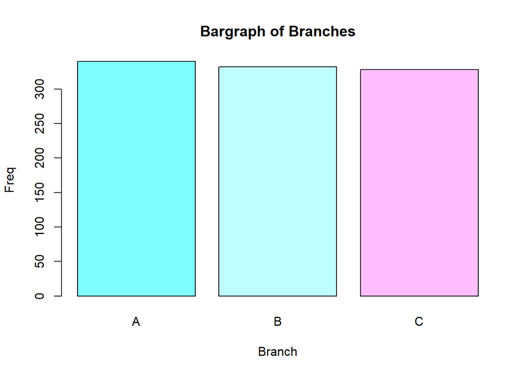

```r
#
barplot(table(sup$Branch),
main = "Bargraph of Branches",
xlab = "Branch",
ylab = "Freq",
col = cm.colors(4),
horiz = FALSE)
```

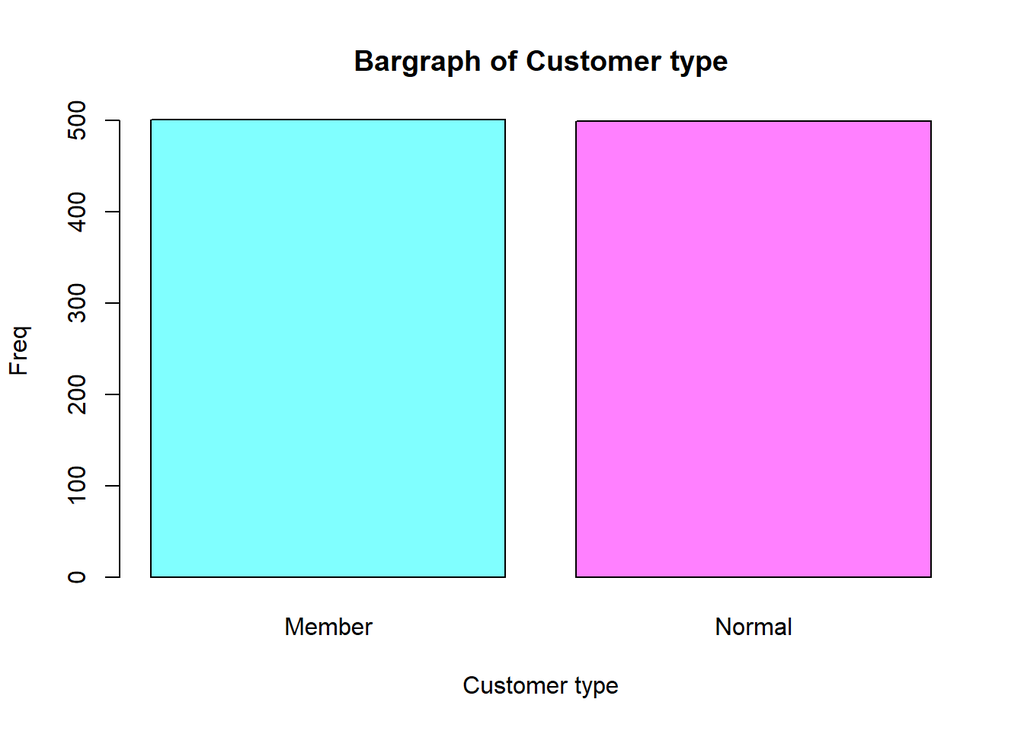

```r
#
barplot(table(sup$Customer.type),
main = "Bargraph of Customer type",
xlab = "Customer type",
ylab = "Freq",
col = cm.colors(2),
horiz = FALSE)
```

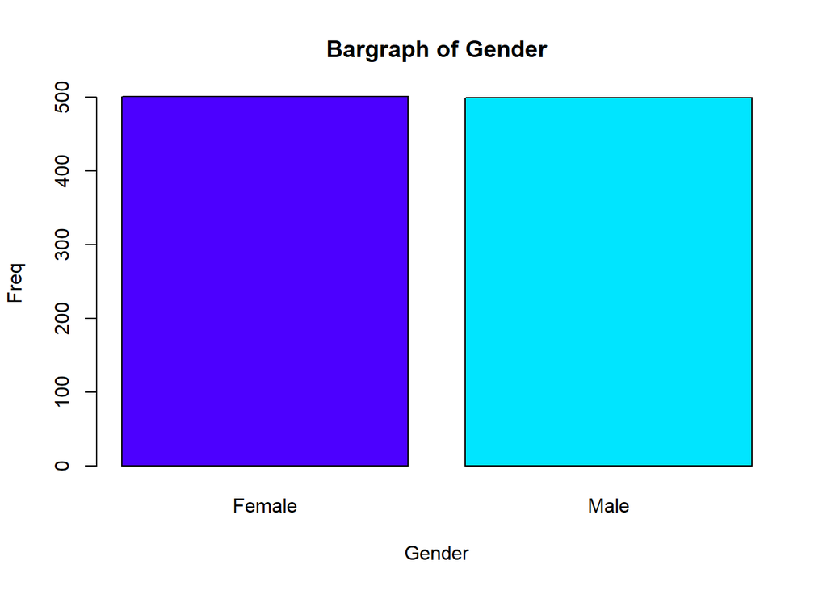

```r
#
barplot(table(sup$Gender),
main = "Bargraph of Gender",
xlab = "Gender",
ylab = "Freq",
col = topo.colors(2),
horiz = FALSE)
```

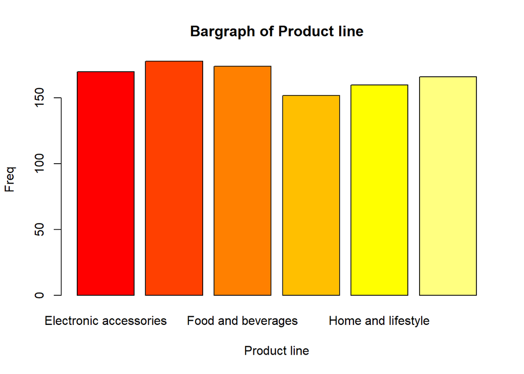

```r
#
barplot(table(sup$Product.line),
main = "Bargraph of Product line",
xlab = "Product line",
ylab = "Freq",
col = heat.colors(6),
horiz = FALSE)
```

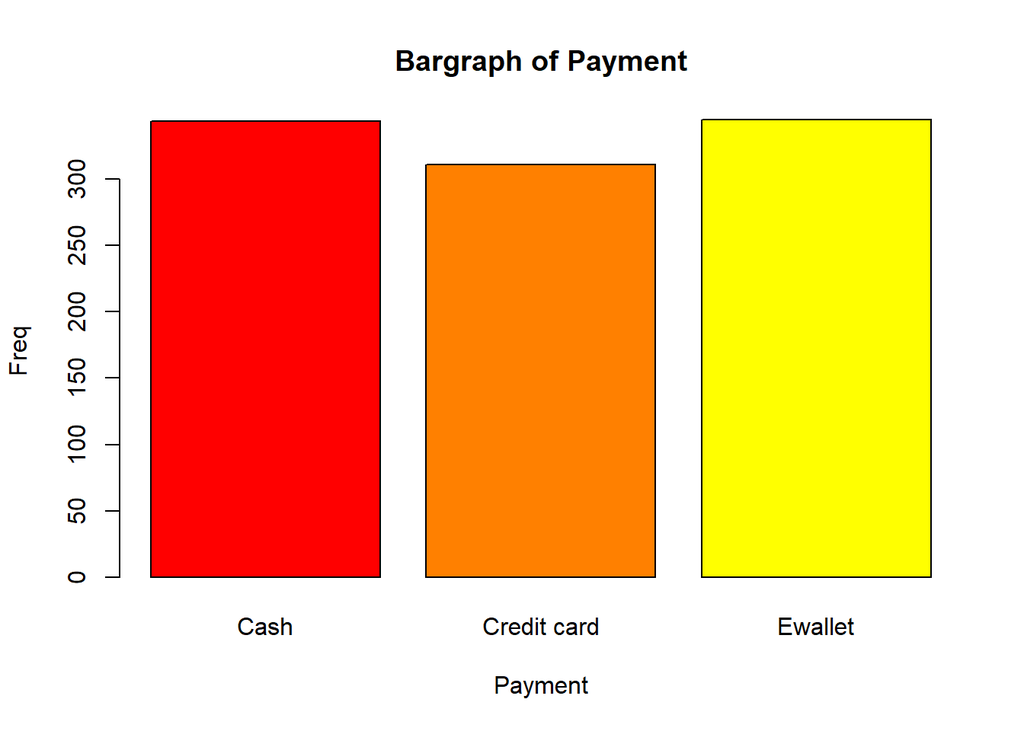

```r
#
barplot(table(sup$Payment),
main = "Bargraph of Payment",
xlab = "Payment",
ylab = "Freq",
col = heat.colors(3),
horiz = FALSE)
```

### Histograms

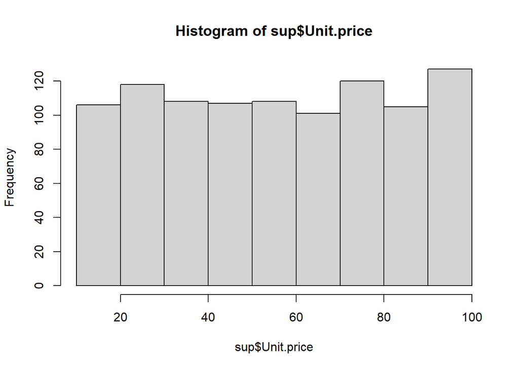

```r
hist(sup$Unit.price)
```

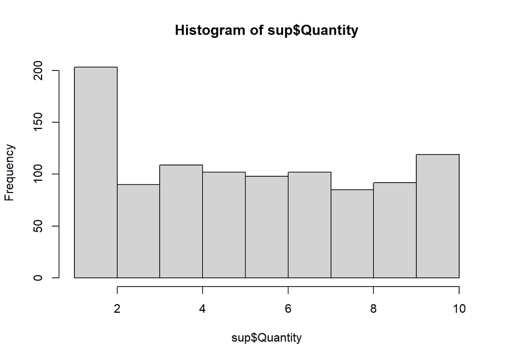

```r
hist(sup$Quantity)
```

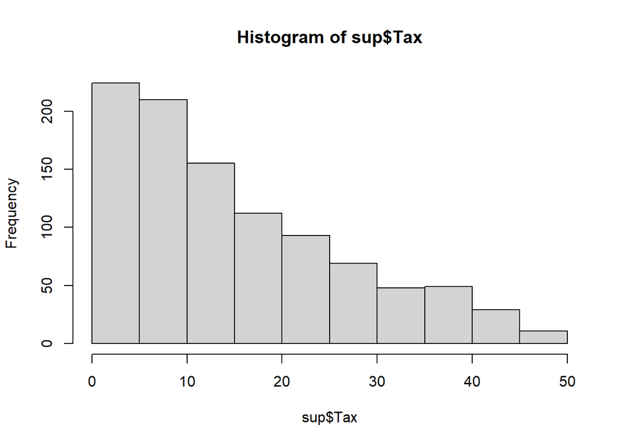

```r
hist(sup$Tax)
```

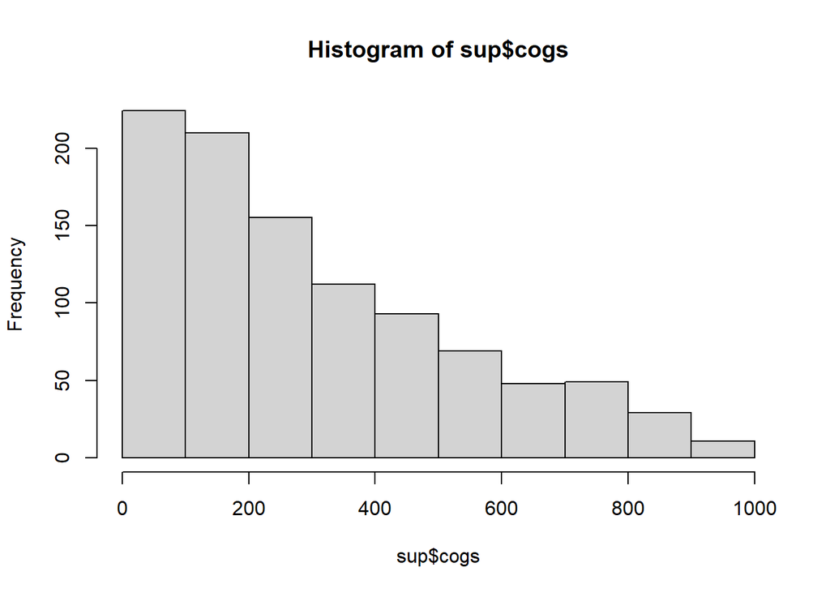

```r
hist(sup$cogs)
```

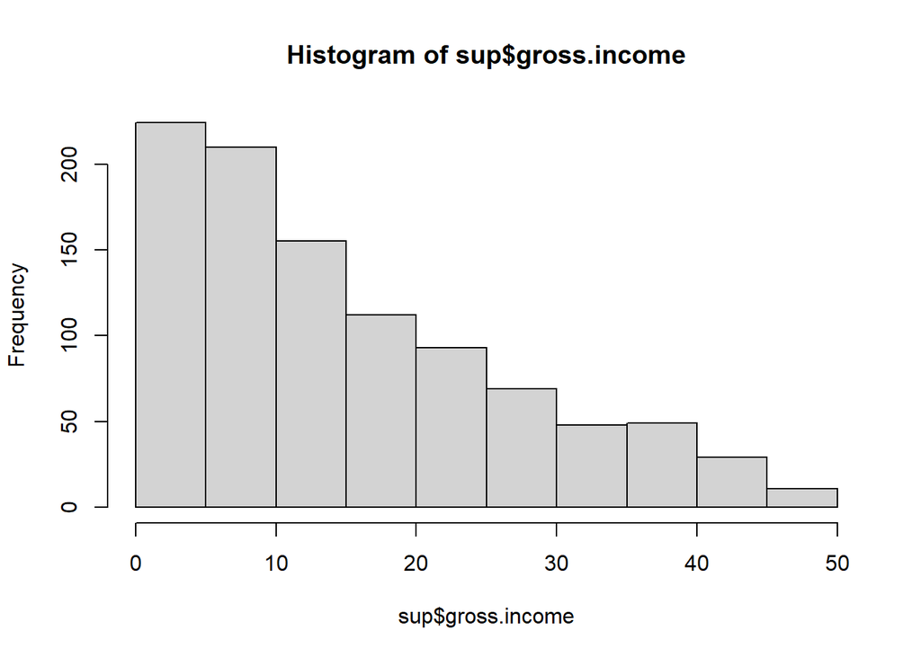

```r
hist(sup$gross.income)
```

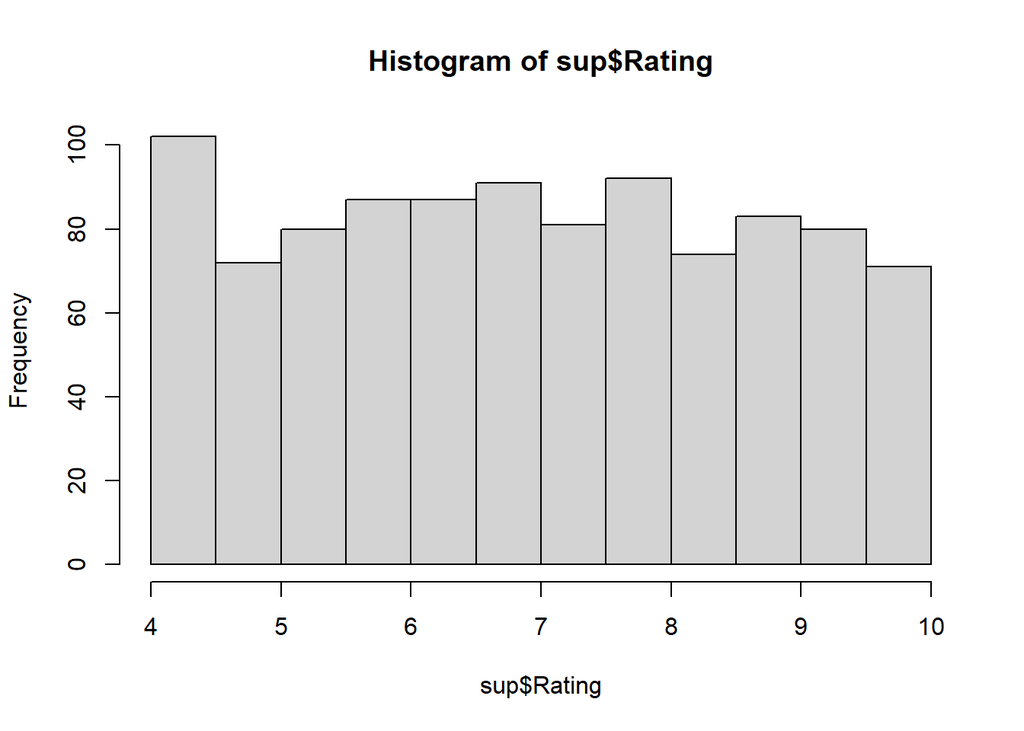

```r
hist(sup$Rating)
```

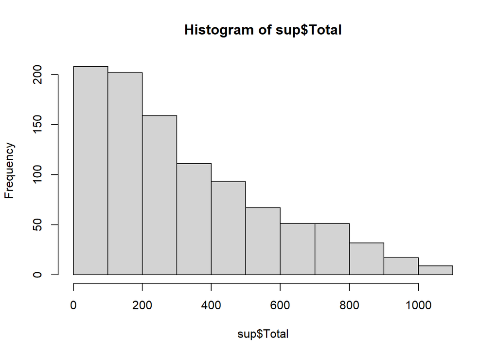

```r
hist(sup$Total)
```

## Bivariate Analysis

### Plots

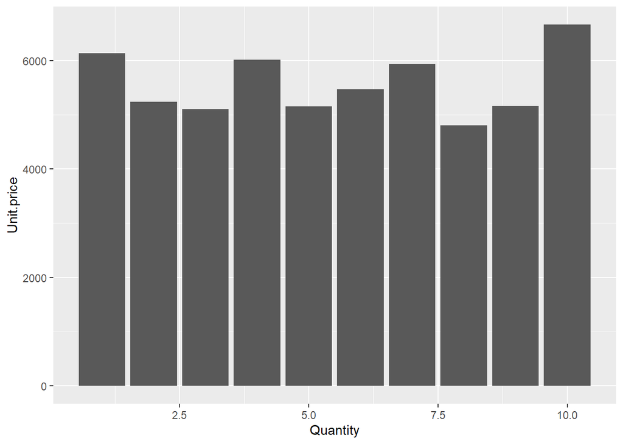

```r
library(ggplot2)
ggplot(data=sup, aes(x=Quantity, y=Unit.price)) +
geom_bar(stat="identity")
```

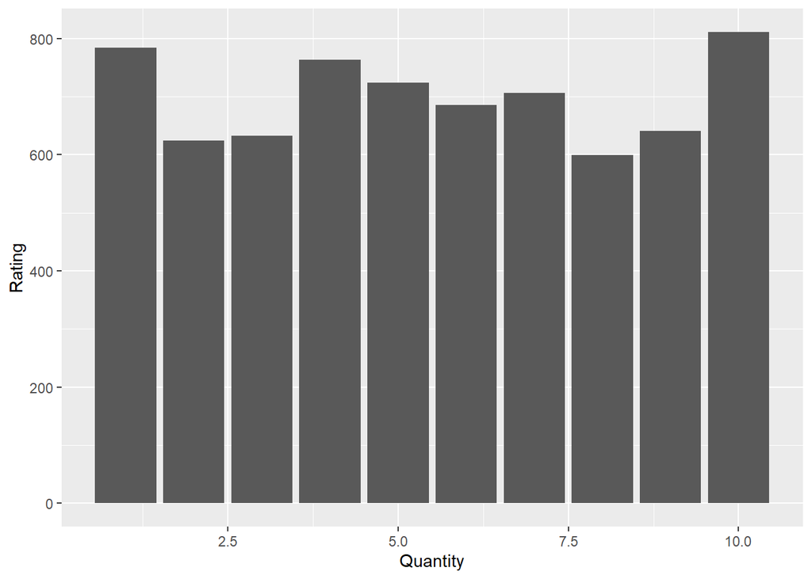

```r
library(ggplot2)
ggplot(data=sup, aes(x=Quantity, y=Rating)) +
geom_bar(stat="identity")
```

```r
# Creating a Dataframe with numeric variables only
sup1 = sup[, c(6,7,8,12,14:16)]

head(sup1)
```

```
##   Unit.price Quantity     Tax   cogs gross.income Rating    Total
## 1      74.69        7 26.1415 522.83      26.1415    9.1 548.9715
## 2      15.28        5  3.8200  76.40       3.8200    9.6  80.2200
## 3      46.33        7 16.2155 324.31      16.2155    7.4 340.5255
## 4      58.22        8 23.2880 465.76      23.2880    8.4 489.0480
## 5      86.31        7 30.2085 604.17      30.2085    5.3 634.3785
## 6      85.39        7 29.8865 597.73      29.8865    4.1 627.6165
```

### Covariance

```r
# Finding the covariance of the feature variables
cov(sup1)
```

```
##                Unit.price     Quantity          Tax        cogs gross.income
## Unit.price    701.9653313   0.83477848  196.6683401  3933.36680  196.6683401
## Quantity        0.8347785   8.54644645   24.1495704   482.99141   24.1495704
## Tax           196.6683401  24.14957038  137.0965941  2741.93188  137.0965941
## cogs         3933.3668019 482.99140761 2741.9318829 54838.63766 2741.9318829
## gross.income  196.6683401  24.14957038  137.0965941  2741.93188  137.0965941
## Rating         -0.3996675  -0.07945646   -0.7333003   -14.66601   -0.7333003
## Total        4130.0351420 507.14097799 2879.0284770 57580.56954 2879.0284770
##                    Rating       Total
## Unit.price    -0.39966752  4130.03514
## Quantity      -0.07945646   507.14098
## Tax           -0.73330028  2879.02848
## cogs         -14.66600553 57580.56954
## gross.income  -0.73330028  2879.02848
## Rating         2.95351823   -15.39931
## Total        -15.39930581 60459.59802
```

### Correlation

```r
# Finding the correlation coefficients of feature variables
cor(sup1)
```

```
##                Unit.price    Quantity        Tax       cogs gross.income
## Unit.price    1.000000000  0.01077756  0.6339621  0.6339621    0.6339621
## Quantity      0.010777564  1.00000000  0.7055102  0.7055102    0.7055102
## Tax           0.633962089  0.70551019  1.0000000  1.0000000    1.0000000
## cogs          0.633962089  0.70551019  1.0000000  1.0000000    1.0000000
## gross.income  0.633962089  0.70551019  1.0000000  1.0000000    1.0000000
## Rating       -0.008777507 -0.01581490 -0.0364417 -0.0364417   -0.0364417
## Total         0.633962089  0.70551019  1.0000000  1.0000000    1.0000000
##                    Rating      Total
## Unit.price   -0.008777507  0.6339621
## Quantity     -0.015814905  0.7055102
## Tax          -0.036441705  1.0000000
## cogs         -0.036441705  1.0000000
## gross.income -0.036441705  1.0000000
## Rating        1.000000000 -0.0364417
## Total        -0.036441705  1.0000000
```

### Correlation Matrix

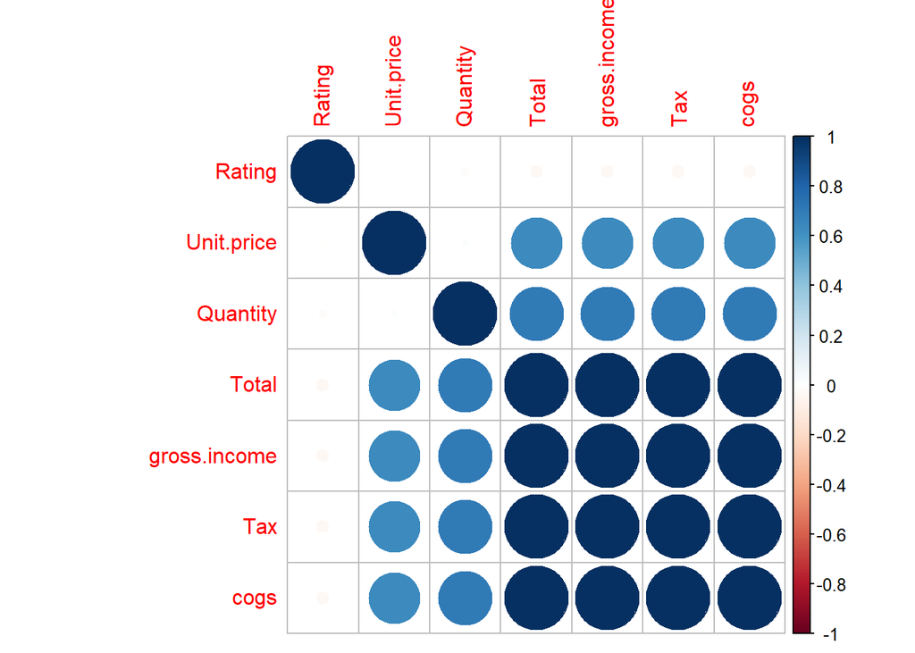

```r
# Creating a correlation matrix
library('corrplot')
corrplot(cor(sup1), order = "hclust")
```

### Scatter Plots

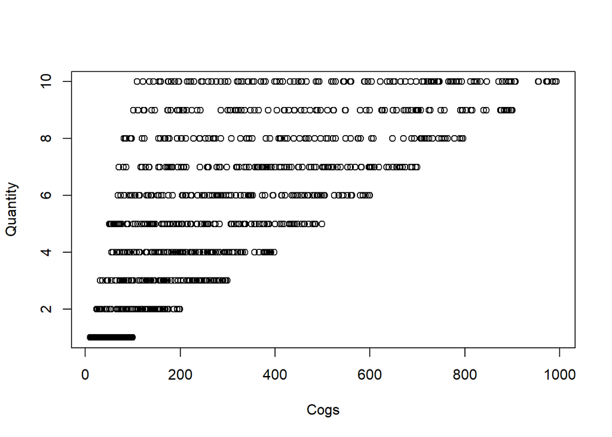

```r
# Plotting a scatterplot between Cogs and Quantity
plot(sup$cogs, sup$Quantity, xlab="Cogs", ylab="Quantity")
```

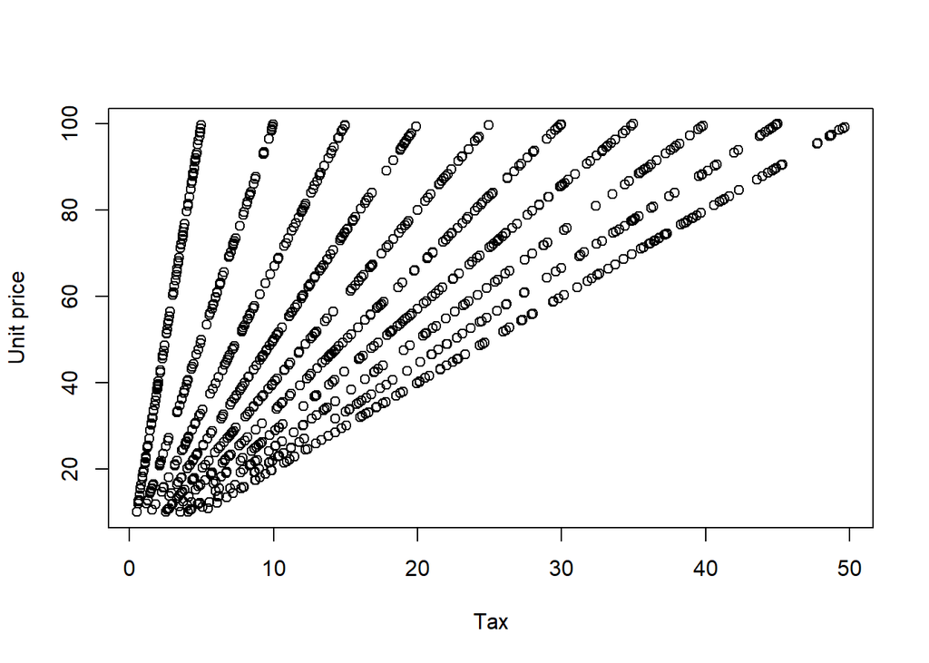

```r
# Plotting a scatterplot between Tax and Unit price
plot(sup$Tax, sup$Unit.price, xlab="Tax", ylab="Unit price")
```

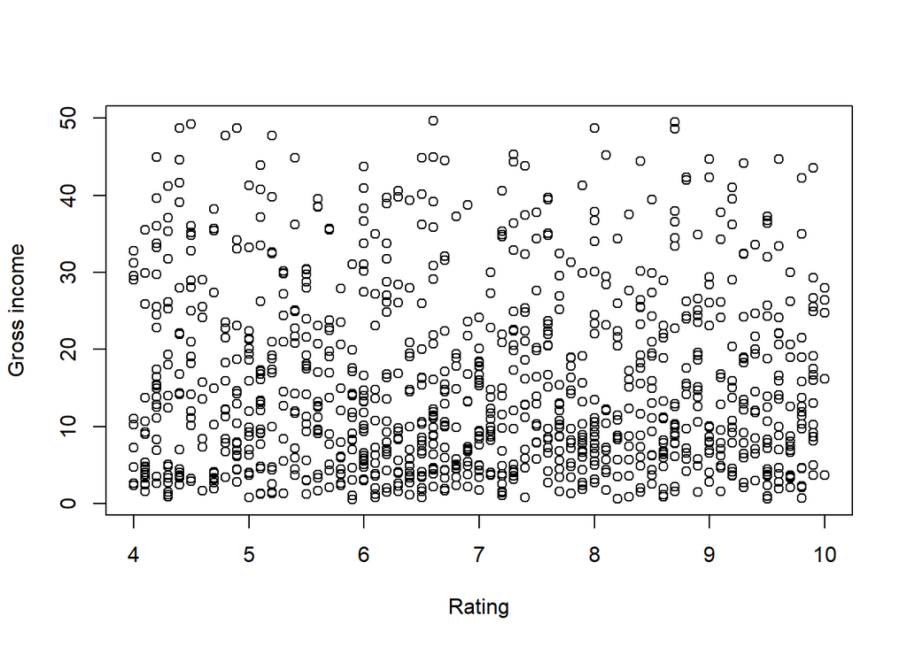

```r
# Plotting a scatterplot between Rating and Gross income
plot(sup$Rating, sup$gross.income, xlab="Rating", ylab="Gross income")
```

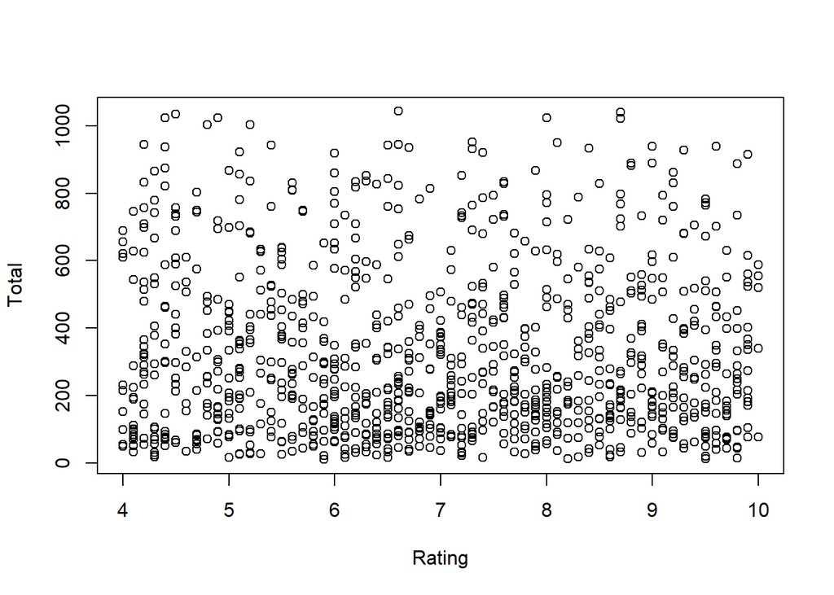

```r
# Plotting a scatterplot between Rating and Total
plot(sup$Rating, sup$Total, xlab="Rating", ylab="Total")
```

### Observations

- The branch with the most customers was Branch A.
- Most customers were members and others normal customers.
- Most customers were females compared to males.
- Fashion accessories were the most bought products.
- Most customers payed using Ewallets.
- Most customers bought 1 - 2 items per sale.
- Most items had taxes ranging from 0 - 15.
- Most items had cogs between 0 - 200.
- Most customers rated 4.
- Tax, Cogs, and Total are highly correlated according to the correlation matrix.

# Implementing the Solution

## Feature Selection

### Filter Method

```r
# Creating a numeric only dataset
sp = sup[, c(6,7,8,12,14:16)]
head(sp)
```

```
##   Unit.price Quantity     Tax   cogs gross.income Rating    Total
## 1      74.69        7 26.1415 522.83      26.1415    9.1 548.9715
## 2      15.28        5  3.8200  76.40       3.8200    9.6  80.2200
## 3      46.33        7 16.2155 324.31      16.2155    7.4 340.5255
## 4      58.22        8 23.2880 465.76      23.2880    8.4 489.0480
## 5      86.31        7 30.2085 604.17      30.2085    5.3 634.3785
## 6      85.39        7 29.8865 597.73      29.8865    4.1 627.6165
```

```r
# Loading the required libraries
#
library(caret)
```

```r
library(corrplot)

# Getting the correlations of the variables.
#
correlationMatrix <- cor(sp)
```

```r
# Find attributes that are highly correlated
#
hc <- findCorrelation(correlationMatrix, cutoff=0.75)

# Showing the highly correlated attributes
#
names(sp[,hc])
```

```
## [1] "cogs"  "Total" "Tax"
```

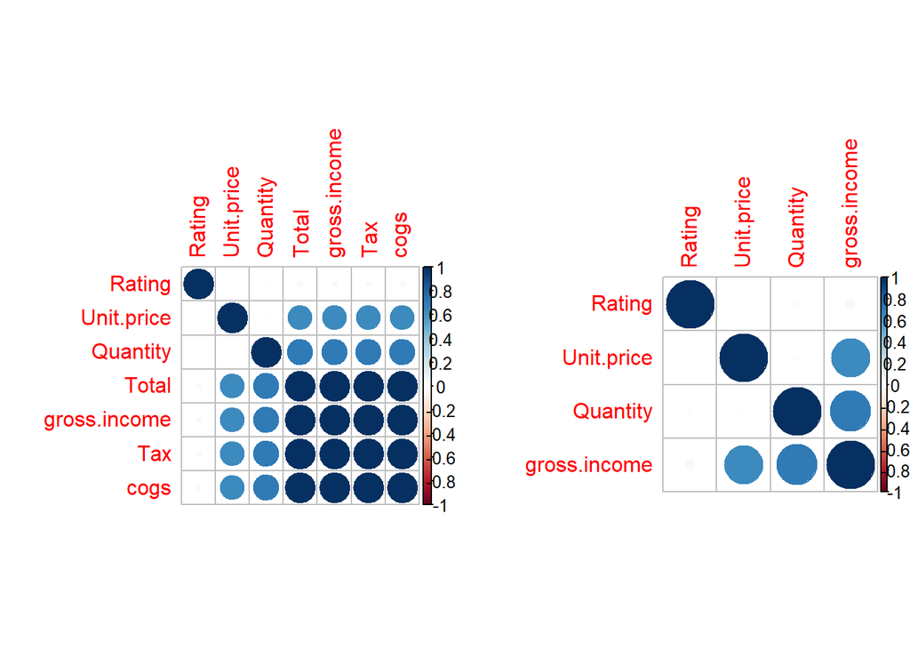

```r
# Removing Redundant Features
#
sp2<-sp[-hc]

# Performing our graphical comparison
#
par(mfrow = c(1, 2))
corrplot(correlationMatrix, order = "hclust")
corrplot(cor(sp2), order = "hclust")
```

### Embedded Method

```r
# Loading the required library
#
library(wskm)
# Creating a model
#
set.seed(2)
model <- ewkm(sp, 3, lambda=2, maxiter=1000)
```

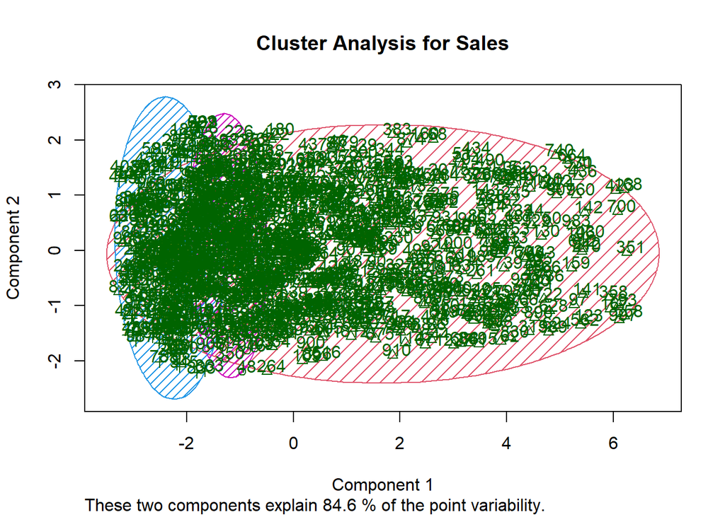

```r
# Loading the required library
#
library("cluster")

# Cluster Plot against 1st and 2nd principal components
#
clusplot(sp, model$cluster, color=TRUE, shade=TRUE, labels=3, lines=1, main='Cluster Analysis for Sales')
```

```r
# Getting the weights in percentages
round(model$weights*100,2)
```

```
##   Unit.price Quantity Tax cogs gross.income Rating Total
## 1          0        0  50    0           50   0.00     0
## 2          0        0   0    0            0  99.99     0
## 3          0        0  50    0           50   0.00     0
```

### Wrapper Method

```r
# Loading the required libraries
#
library(clustvarsel)
library(mclust)

# Performing sequential forward headlong search
#
out = clustvarsel(sp, G = 1:5, search = c("headlong"))
out
```

```
## ------------------------------------------------------
## Variable selection for Gaussian model-based clustering
## Headlong (forward/backward) search
## ------------------------------------------------------
##
##  Variable proposed Type of step   BICclust Model G     BICdiff Decision
##                Tax          Add  -7382.354     V 4    389.0238 Accepted
##       gross.income          Add  55575.522   VEV 3   2961.1245 Accepted
##             Rating          Add -15921.695   VVI 5 -67563.5280 Rejected
##                Tax       Remove  -7383.226     V 4   2961.9966 Rejected
##
## Selected subset: Tax, gross.income
```

```r
# Building the clustering model
#
sp_sub = sp[,out$subset]
mod = Mclust(sp_sub, G = 1:5)
summary(mod)
```

```
## ----------------------------------------------------
## Gaussian finite mixture model fitted by EM algorithm
## ----------------------------------------------------
##
## Mclust VEV (ellipsoidal, equal shape) model with 2 components:
##
##  log-likelihood    n df      BIC      ICL
##        27364.17 1000 10 54659.26 54524.45
##
## Clustering table:
##   1   2
## 564 436
```

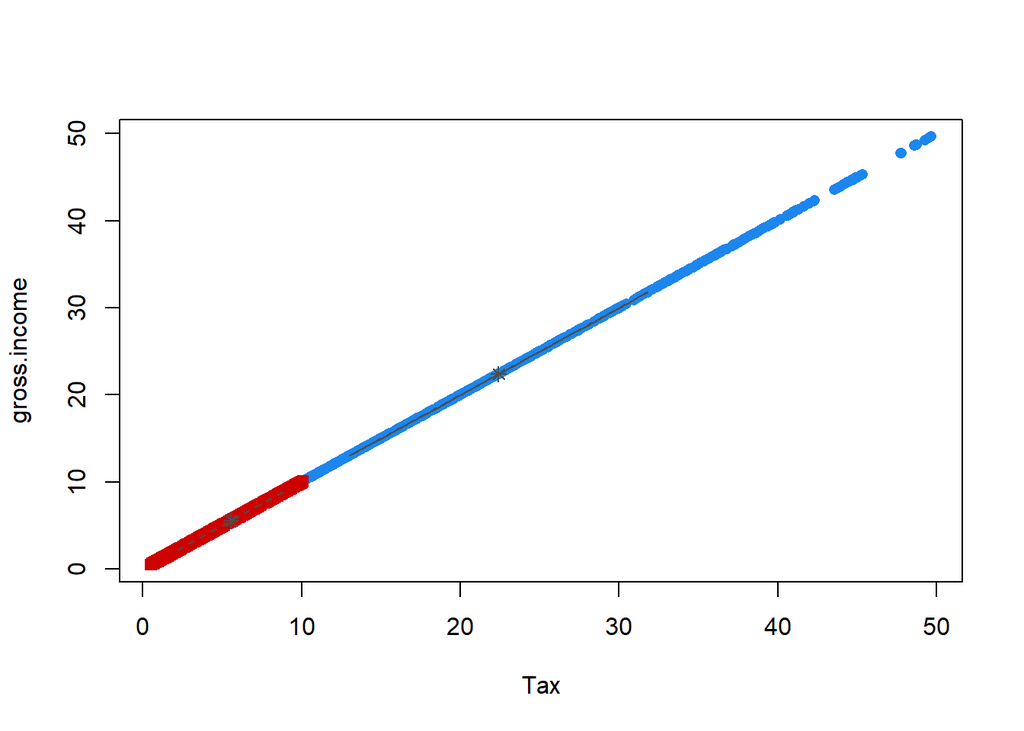

```r
# Plotting the model
#
plot(mod,c("classification"))
```

## Observations

- From Filter method we can see that tax, cogs, and total are highly correlated and therefore should be removed.
- From the Wrapper method tax and gross income are selected to be added and the other variables rejected.

# Recommendations

From the analysis the following recommendations can be made the filter method is the best to use for feature selection since it removes features which are highly correlated. Tax and gross income are the best feature to consider in our dataset when doing analysis.